# Design based estimators and pooling

Beth Babcock

2024-07-14

This tutorial gives some practice in working with design-based estimators, including different pooling methods, using the data sets included with the tool. First load the libraries:

```r
# devtools::install_github("ebabcock/BycatchEstimator")  #Make sure library is installed and up to date
library(BycatchEstimator)
library(MuMIn)
```

Then look at the simulated longline data. This is generated from Phil Goodyear’s species distribution and longline fishery simulator. The data in both the logbook and observer data are at trip-by-trip. There is a variable called *trip* which can be used to match the sampled trips in the observer data to the corresponding trips in the logbook.

```r
print(head(LLSIM_BUM_Example_observer))
```

```
## # A tibble: 6 × 22
##    ...1 trip    Year month  gear light fleet  bait  hook hooks  sets   SWO   BUM
##   <dbl> <chr>  <dbl> <dbl> <dbl> <dbl> <dbl> <dbl> <dbl> <dbl> <dbl> <dbl> <dbl>
## 1     2 10.19…  1990     4    10     1     1     2     4  0.5      1     4     0
## 2     3 10.19…  1990     7    10     1     1     2     4  4.5      9    31     0
## 3     4 10.19…  1990     8    10     1     1     2     4  1.15     2     7     0
## 4     5 10.19…  1991     2    10     1     1     2     4  0.5      1     2     0
## 5     6 10.19…  1992    10    10     1     1     2     4  1.2      2     7     0
## 6     7 10.19…  1993     5    10     1     1     2     4  2.5      5    14     0
## # ℹ 9 more variables: lat5 <dbl>, lon5 <dbl>, lat <dbl>, lon <dbl>, hbf <dbl>,
## #   habSWO <dbl>, habBUM <dbl>, season <dbl>, area <chr>
```

```r
print(head(LLSIM_BUM_Example_logbook))
```

```
## # A tibble: 6 × 25
##    ...1 trip    Year month  gear light fleet  bait  hook hooks  sets   SWO   BUM
##   <dbl> <chr>  <dbl> <dbl> <dbl> <dbl> <dbl> <dbl> <dbl> <dbl> <dbl> <dbl> <dbl>
## 1     1 1.200…  2009     4     1     1     1     2     1 2         4    14     0
## 2    51 10.19…  1990     1    10     1     1     2     4 0.5       1     2     0
## 3    52 10.19…  1990     1    10     1     1     2     4 1.5       3     4     0
## 4    53 10.19…  1990     1    10     1     1     2     4 1.5       3     8     0
## 5    54 10.19…  1990    10    10     1     1     2     4 0.516     1     5     0
## 6    55 10.19…  1990    10    10     1     1     2     4 3         6    19     0
## # ℹ 12 more variables: lat5 <dbl>, lon5 <dbl>, lat <dbl>, lon <dbl>, hbf <dbl>,
## #   habSWO <dbl>, habBUM <dbl>, trip.05 <dbl>, trips <dbl>, season <dbl>,
## #   area <chr>, unsampledEffort <dbl>
```

To understand how stratified estimators work, let’s stratify by year, fleet and area (N vs. S Atlantic). The bycatch response variable is the catch of blue marlin *BUM* and effort is in *hooks*. Note that the the design-based estimators are calculated in the bycatchSetup function, so many of the inputs for model-based estimation can be left blank and go to their default values (see help file for bycatchSetup). However, if you want to use bycatchFit later, you should include some models in modelTry.

Let’s run this first with no pooling.

```r
setupObj<-bycatchSetup(
 modelTry = c("TMBdelta-Lognormal"),
 obsdat = LLSIM_BUM_Example_observer,
  logdat = LLSIM_BUM_Example_logbook,
  yearVar = "Year",
  obsEffort = "hooks",
  logEffort = "hooks",
  factorNames = c("Year","area","fleet"), #To be sure that factors are not interpreted as numbers
  EstimateIndex = FALSE,
  EstimateBycatch = TRUE,  #Should be true
  logNum = NA,
  sampleUnit = "trips",
  complexModel = formula(y~Year+area+fleet),  #Complex model not used in this set
  simpleModel = formula(y~Year+area), # This defines strata for the models, and also some output files
  indexModel = formula(y~Year+area),  # not used
  designMethods =c("Ratio","Delta"),  #THis specifies the design-based methods to use
  designVars=c("Year","area","fleet"),  #Stratification variables
  designPooling = FALSE,  #No pooling.  #Bycatch will be estimated at 0 for strata with no observer data
  baseDir = getwd(),
  runName = "LLSIMBUMNoPool",
  runDescription = "LLSIm BUM with no pooling",
  common = "Blue marlin",
  sp = "Makaira nigricans",
  obsCatch = "BUM",
  catchUnit = "number",
  catchType = "catch"
)
```

This part of the tool doesn’t make any graphs, but it did print out the data in files labelled DesignYear and DesignStrata. We can read them in and plot them. The annual summaries are also in the object made by bycatchSetup, were we can access them. For example, the following reads in the annual summary and plots the ratio estimator.

```r
yearSum<-read.csv("Output LLSIMBUMNoPool/Blue marlin catch/Blue marlincatchDesignYear.csv")
head(yearSum)
```

```
##   Year ratioMean  ratioSE deltaMean  deltaSE
## 1 1990  20338.93 2365.412  21834.44 3256.517
## 2 1991  20902.94 2114.211  26186.30 4795.402
## 3 1992  20413.93 1807.436  21709.11 2875.443
## 4 1993  27314.22 2455.949  26133.96 3055.285
## 5 1994  22165.95 1655.184  21988.06 2510.534
## 6 1995  17102.12 1414.059  18839.08 2119.837
```

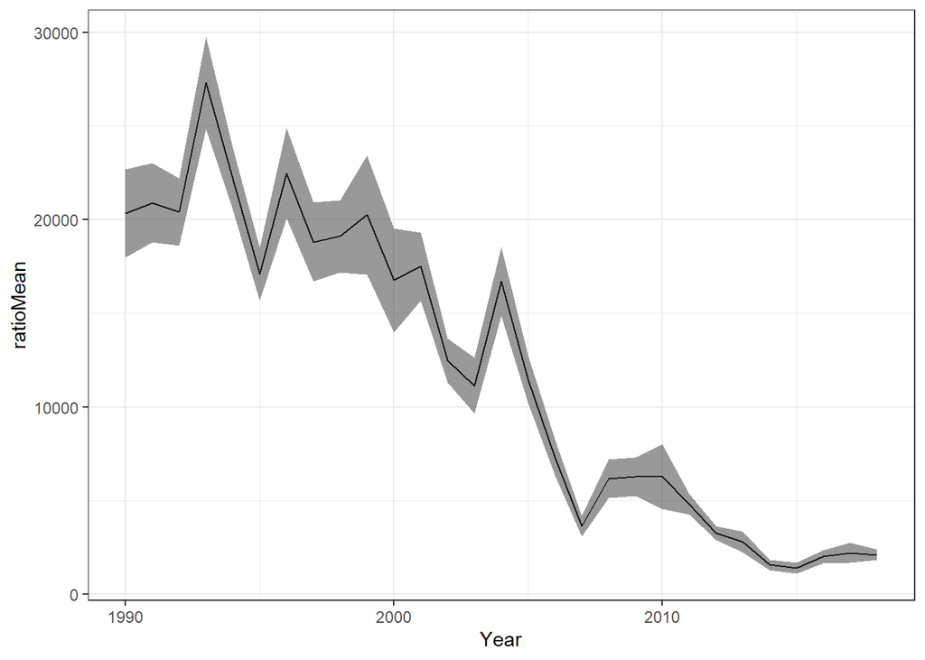

```r
ggplot(yearSum,aes(x=Year,y=ratioMean))+
    geom_line()+
    geom_ribbon(aes(ymin=ratioMean-ratioSE,ymax=ratioMean+ratioSE),alpha=0.5)
```

```r
setupObj<-bycatchSetup(
 modelTry = c("TMBdelta-Lognormal"),
 obsdat = LLSIM_BUM_Example_observer,
  logdat = LLSIM_BUM_Example_logbook,
  yearVar = "Year",
  obsEffort = "hooks",
  logEffort = "hooks",
  factorNames = c("Year","area","fleet"),
  EstimateIndex = FALSE,
  EstimateBycatch = TRUE,
  logNum = NA,
  sampleUnit = "trips",
  complexModel = formula(y~Year+area+fleet),
  simpleModel = formula(y~Year+area+fleet),  # added fleet here
  indexModel = formula(y~Year+area),
  designMethods =c("Ratio","Delta"),
  designVars=c("Year","area","fleet"),
  designPooling = FALSE,
  baseDir = getwd(),
  runName = "LLSIMBUMNoPool",
  runDescription = "LLSIm BUM with no pooling",
  common = "Blue marlin",
  sp = "Makaira nigricans",
  obsCatch = "BUM",
  catchUnit = "number",
  catchType = "catch"
)
```

```r
setupObj<-bycatchSetup(
 modelTry = c("TMBdelta-Lognormal"),
 obsdat = LLSIM_BUM_Example_observer,
  logdat = LLSIM_BUM_Example_logbook,
  yearVar = "Year",
  obsEffort = "hooks",
  logEffort = "hooks",
  factorNames = c("Year","area","fleet"),
  EstimateIndex = FALSE,
  EstimateBycatch = TRUE,
  logNum = NA,
  sampleUnit = "trips",
  complexModel = formula(y~Year+area+fleet),
  simpleModel = formula(y~Year+area+fleet),
  indexModel = formula(y~Year+area),
  designMethods =c("Ratio","Delta"),
  designVars=c("Year","area","fleet"),
  designPooling = TRUE,  #make this true
  poolTypes = c("adjacent","all","all"),  #Pool by adjacent years, and all fleets or all areas
  pooledVar = c("Year","area","fleet"),  #Pool variables in this order
  adjacentNum = c(2,NA,NA),  #Pool 2 years before and after
  minStrataUnit = 2,  #Pool if there are fewer than 2 trips in a stratum
  baseDir = getwd(),
  runName = "LLSIMBUMPool2",
  runDescription = "LLSIm BUM with pooling 2 or fewer trips",
  common = "Blue marlin",
  sp = "Makaira nigricans",
  obsCatch = "BUM",
  catchUnit = "number",
  catchType = "catch"
)
```

```r
pooling<-read.csv("Output LLSIMBUMPool2/Blue marlin catch/Blue marlincatchPooling.csv")
head(pooling)
```

```
##   Year area fleet totalUnits totalEffort units   effort needs.pooling pooled.n
## 1 1990    N     1       1445    5442.777    71  248.057         FALSE       71
## 2 1990    N     2        787   27553.331    48 1514.269         FALSE       48
## 3 1990    S     2        887   51579.501    41 2059.257         FALSE       41
## 4 1990    S     3         99    5237.189     4  234.972         FALSE        4
## 5 1991    N     1       1339    6007.066    63  311.781         FALSE       63
## 6 1991    N     2        777   27417.542    33  953.047         FALSE       33
##   poolnum pooledTotalUnits pooledTotalEffort stratum
## 1       0             1445          5442.777       1
## 2       0              787         27553.331       2
## 3       0              887         51579.501       3
## 4       0               99          5237.189       4
## 5       0             1339          6007.066       5
## 6       0              777         27417.542       6
```

```r
filter(pooling,Year %in% 1994:2000, fleet==3, area=="N")
```

```
##   Year area fleet totalUnits totalEffort units  effort needs.pooling pooled.n
## 1 1996    N     3         16     716.070     2  56.745         FALSE        6
## 2 1997    N     3         23     618.744     3  72.905         FALSE        3
## 3 1998    N     3         32    1048.560     1  43.460         FALSE       16
## 4 1999    N     3         77    2462.130     4  30.343         FALSE        4
## 5 2000    N     3        106    3446.658     6 182.930         FALSE        6
##   poolnum pooledTotalUnits pooledTotalEffort stratum
## 1       1               71          2383.374      27
## 2       0               23           618.744      32
## 3       1              254          8292.162      37
## 4       0               77          2462.130      42
## 5       0              106          3446.658      47
```

You can see that years 1996 and 1998 both needed to be pooled (*units* of 2 or less). There was no effort in 1994 or 1995 in this area and fleet. So the pool for year 1996 was 1996 to 1998, which gave a pooled sample size (*pooled.n*) of 2+3+1=6. This was above minStrataUnit, so that pool was sufficient and *poolnum* was one, meaning no further pooling. Does the *pooled.n* value for 1998 make sense?

Let’s look at a stratum that needed more pooling.

```r
print(filter(pooling,Year %in% 2002:2006, fleet==1))
```

```
##   Year area fleet totalUnits totalEffort units  effort needs.pooling pooled.n
## 1 2002    N     1        919    6151.136    51 310.138         FALSE       51
## 2 2002    S     1         17      60.102     0   0.000         FALSE        4
## 3 2003    N     1        899    6195.748    40 240.244         FALSE       40
## 4 2003    S     1          9      48.480     1   6.480         FALSE        3
## 5 2004    N     1        935    6470.181    53 347.879         FALSE       53
## 6 2004    S     1          5      16.000     0   0.000         FALSE      226
## 7 2005    N     1        825    5319.083    39 291.849         FALSE       39
## 8 2006    N     1        825    5160.586    42 298.967         FALSE       42
##   poolnum pooledTotalUnits pooledTotalEffort stratum
## 1       0              919          6151.136      57
## 2       1               63           286.179      60
## 3       0              899          6195.748      63
## 4       1               50           234.780      66
## 5       0              935          6470.181      69
## 6       2             4434         29421.316      72
## 7       0              825          5319.083      75
## 8       0              825          5160.586      80
```

```r
nrow(filter(LLSIM_BUM_Example_observer,Year %in% 2002:2006,fleet==1))
```

```
## [1] 226
```

You can plot what fraction of the strata are pooled to each level as a diagnostic that the pooling works as intended.

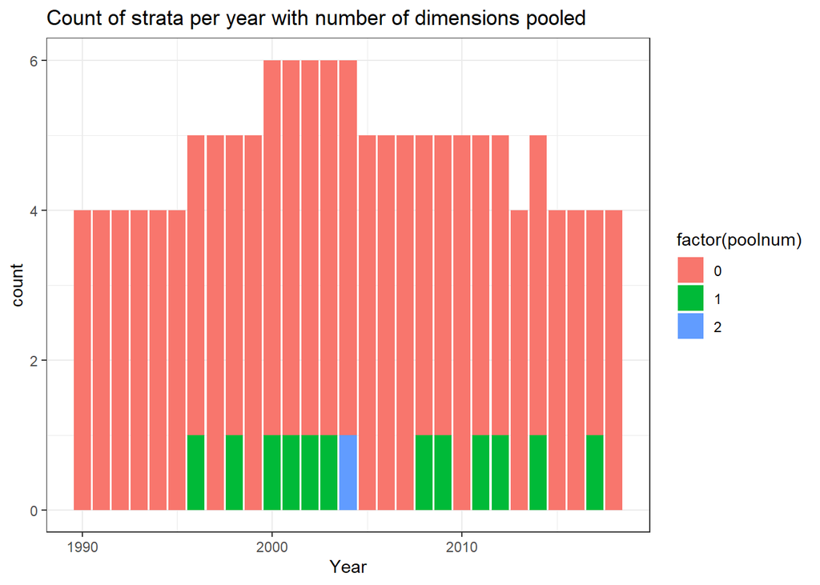

```r
ggplot(pooling,aes(x=Year,fill=factor(poolnum)))+
  geom_bar()+
  ggtitle("Count of strata per year with number of dimensions pooled")
```

Now have a higher minimum number of observed trips.

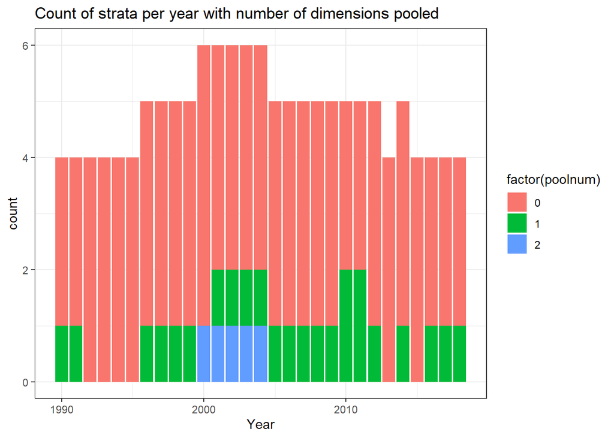

```r
setupObj<-bycatchSetup(
 modelTry = c("TMBdelta-Lognormal"),
 obsdat = LLSIM_BUM_Example_observer,
  logdat = LLSIM_BUM_Example_logbook,
  yearVar = "Year",
  obsEffort = "hooks",
  logEffort = "hooks",
  factorNames = c("Year","area","fleet"),
  EstimateIndex = FALSE,
  EstimateBycatch = TRUE,
  logNum = NA,
  sampleUnit = "trips",
  complexModel = formula(y~Year+area+fleet),
  simpleModel = formula(y~Year+area+fleet),
  indexModel = formula(y~Year+area),
  designMethods =c("Ratio","Delta"),
  designVars=c("Year","area","fleet"),
  designPooling = TRUE,  #make this true
  poolTypes = c("adjacent","all","all"),
  pooledVar = c("Year","area","fleet"),
  adjacentNum = c(2,NA,NA),
  minStrataUnit = 5,  #Pool if there are 5 or fewer trips in a stratum
  baseDir = getwd(),
  runName = "LLSIMBUMPool5",  #update name
  runDescription = "LLSIm BUM with pooling <5 trips",    #update descritipn
  common = "Blue marlin",
  sp = "Makaira nigricans",
  obsCatch = "BUM",
  catchUnit = "number",
  catchType = "catch"
)
pooling<-read.csv("Output LLSIMBUMPool5/Blue marlin catch/Blue marlincatchPooling.csv")
ggplot(pooling,aes(x=Year,fill=factor(poolnum)))+
  geom_bar()+
  ggtitle("Count of strata per year with number of dimensions pooled")
```

Another option for pooling is to add another column to the data that is a more aggregated variable to use when the original data doesn’t meet the minimum sample size requirement. For example, if the strata were months, the variable to pool on (if needed) could be season. Let’s try that.

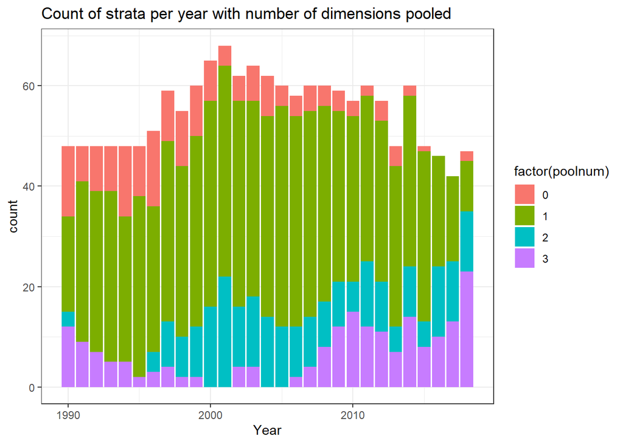

```r
setupObj<-bycatchSetup(
 modelTry = c("TMBdelta-Lognormal"),
 obsdat = LLSIM_BUM_Example_observer,
  logdat = LLSIM_BUM_Example_logbook,
  yearVar = "Year",
  obsEffort = "hooks",
  logEffort = "hooks",
  factorNames = c("Year","area","fleet","month"),
  EstimateIndex = FALSE,
  EstimateBycatch = TRUE,
  logNum = NA,
  sampleUnit = "trips",
  complexModel = formula(y~Year+area+month),
  simpleModel = formula(y~Year+area+fleet),
  indexModel = formula(y~Year+area),
  designMethods =c("Ratio","Delta"),
  designVars=c("Year","area","fleet","month"), #Added month to the model
  designPooling = TRUE,
  poolTypes = c("adjacent","all","all","pooledVar"),
  pooledVar = c("Year","area","fleet","season"),
  adjacentNum = c(2,NA,NA),
  minStrataUnit = 5,  #Pool if there are 5 or fewer trips in a stratum
  baseDir = getwd(),
  runName = "LLSIMBUMPoolMonth",  #update name
  runDescription = "LLSIm BUM with pooling <5 trips with mont",    #update description
  common = "Blue marlin",
  sp = "Makaira nigricans",
  obsCatch = "BUM",
  catchUnit = "number",
  catchType = "catch"
)
pooling<-read.csv("Output LLSIMBUMPoolMonth/Blue marlin catch/Blue marlincatchPooling.csv")
ggplot(pooling,aes(x=Year,fill=factor(poolnum)))+
  geom_bar()+
  ggtitle("Count of strata per year with number of dimensions pooled")
```

This stratification scheme requires pooling for nearly all the strata. It still works, but the resulting estimates will be somewhat smoothed by the pooling process.

## Extra code for making plots

```r
yearSumLong<-pivot_longer(yearSum,ratioMean:deltaSE,names_to = "Method") %>%
  mutate(parameter=ifelse(grepl("Mean",Method),"Mean","SE"),
    Method=sub("Mean","",Method),
    Method=sub("SE","",Method)) %>%
  pivot_wider(names_from=parameter,values_from=value)
head(yearSumLong)
```

```
## # A tibble: 6 × 4
##    Year Method   Mean    SE
##   <int> <chr>   <dbl> <dbl>
## 1  1990 ratio  20339. 2365.
## 2  1990 delta  21834. 3257.
## 3  1991 ratio  20903. 2114.
## 4  1991 delta  26186. 4795.
## 5  1992 ratio  20414. 1807.
## 6  1992 delta  21709. 2875.
```

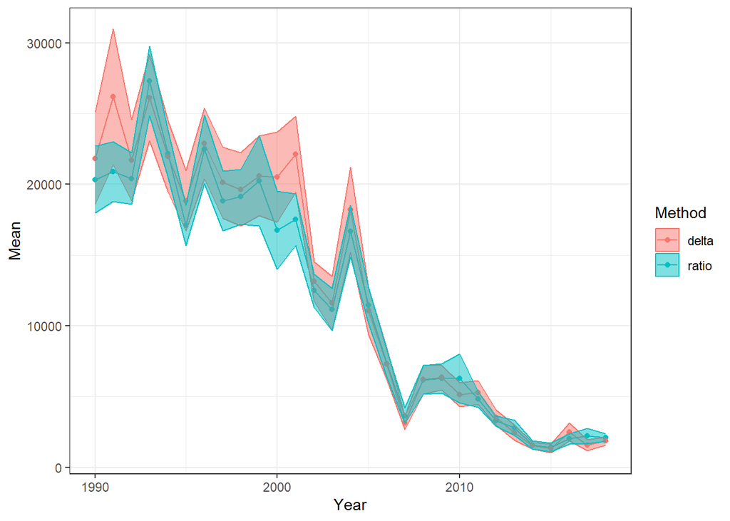

```r
ggplot(yearSumLong,aes(x=Year,y=Mean,ymin=Mean-SE,ymax=Mean+SE,color=Method,fill=Method))+
  geom_line()+
  geom_point()+
  geom_ribbon(alpha=0.5)
```